# LC_tensorflow

### This is part 2 of the Lending Club project, where I will attempt to improve on the KNN model using a Neural Net

### Same dataset as before

|  | loan_amnt | funded_amnt | funded_amnt_inv | installment | annual_inc |
| --- | --- | --- | --- | --- | --- |
| 1273506 | 9600.0 | 9600.0 | 9600.0 | 323.42 | 21900.0 |
| 324024 | 4000.0 | 4000.0 | 4000.0 | 122.93 | 83000.0 |
| 2066630 | 6025.0 | 6025.0 | 6025.0 | 197.00 | 52000.0 |

```
Index(['loan_amnt', 'funded_amnt', 'funded_amnt_inv', 'installment',
       'annual_inc', 'dti', 'delinq_2yrs', 'fico_range_low', 'fico_range_high',
       'inq_last_6mths', 'open_acc', 'pub_rec', 'revol_bal', 'revol_util',
       'total_acc', 'out_prncp', 'out_prncp_inv', 'total_pymnt',
       'total_pymnt_inv', 'total_rec_prncp', 'total_rec_int',
       'total_rec_late_fee', 'recoveries', 'collection_recovery_fee',
       'last_pymnt_amnt', 'last_fico_range_high', 'last_fico_range_low',
       'collections_12_mths_ex_med', 'policy_code', 'acc_now_delinq',
       'chargeoff_within_12_mths', 'delinq_amnt', 'pub_rec_bankruptcies',
       'tax_liens', 'grade_dum', 'FullyPaid'],
      dtype='object')
```

```
MinMaxScaler(copy=True, feature_range=(0, 1))
```

### Given the shape of X_train, the Neural Net will have atleast 35 units for the first layer

```
(4115, 34)
```

```
Train on 4115 samples, validate on 1764 samples
Model: "sequential"
_________________________________________________________________
Layer (type)                 Output Shape              Param #
=================================================================
dense (Dense)                multiple                  1225
_________________________________________________________________
dropout (Dropout)            multiple                  0
_________________________________________________________________
dense_1 (Dense)              multiple                  1260
_________________________________________________________________
dropout_1 (Dropout)          multiple                  0
_________________________________________________________________
dense_2 (Dense)              multiple                  360
_________________________________________________________________
dropout_2 (Dropout)          multiple                  0
_________________________________________________________________
dense_3 (Dense)              multiple                  110
_________________________________________________________________
dropout_3 (Dropout)          multiple                  0
_________________________________________________________________
dense_4 (Dense)              multiple                  11
=================================================================
Total params: 2,966
Trainable params: 2,966
Non-trainable params: 0
_________________________________________________________________
```

### With early stopping the model only took about 20 epochs to train. The results below indicate that validation accuracy is always very high, which highlights the skew in the data (most people pay back the loan). Another problem could be that the dataset is simply too small with only around 6k points. Neural nets typically excel at detecting edge cases, which a larger dataset may be able to capture.

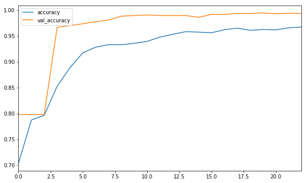

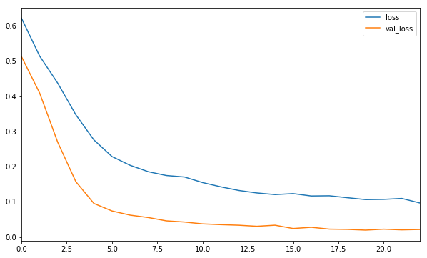

### The Neural Net still crushes the KNN model. The KNN model had an f1-score of about 0.87 for defaulters, which is far lower than the Neural net. Overall, this model is far superior at detecting edge cases and is not harmed by the skew of the data.

Note, that for Fully Paid off loans (1), the f1-score is 100%. The KNN model was already doing quite well with that category so I do not find the perfect score to be suspicious.

```
              precision    recall  f1-score   support

           0       0.99      0.98      0.98       356
           1       0.99      1.00      1.00      1408

   micro avg       0.99      0.99      0.99      1764
   macro avg       0.99      0.99      0.99      1764
weighted avg       0.99      0.99      0.99      1764
```

### If I were to guess at random if potential client would default on a loan or not I would be correct on avearge about $$ \frac{1175*100}{1175+4704} = 20\% $$

### of the time. However, with my Neural Net model that accuracy jumps up to about 99%, allowing LC to make better decisions.

```
FullyPaid
0    1175
1    4704
Name: loan_amnt, dtype: int64
```